# The caret package

Jeffrey Leek

## The caret R package

[figure not shown]

http://caret.r-forge.r-project.org/

## Caret functionality

- Some preprocessing (cleaning)
- preProcess - clean data and setup the features.
- Data splitting
- createDataPartition
- createResample
- createTimeSlices
- Training/testing functions
- train
- predict
- Model comparison
- confusionMatrix - info on how well the model works on new data sets.

## Machine learning algorithms in R

- Linear discriminant analysis
- Regression
- Naive Bayes
- Support vector machines
- Classification and regression trees
- Random forests
- Boosting
- etc.

These are written by different developers and so they have different interfaces.

## Why caret?

Consider this list of different prediction algorithms from different packages. For each algorithm we have created an object called `obj`. Notice that each object has a different class, and that each prediction requires different parameters to be passed to it.

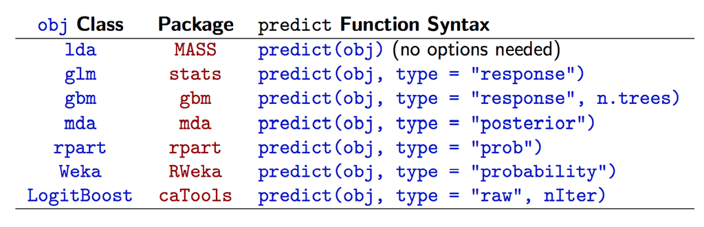

The caret package provides a unifying framework which allows you to predict using just one function and without having to specify all the options.

http://www.edii.uclm.es/~useR-2013/Tutorials/kuhn/user_caret_2up.pdf

## SPAM Example: Data splitting

```r
library(caret); library(kernlab); data(spam)
inTrain <- createDataPartition(y=spam$type,
                              p=0.75, list=FALSE)
training <- spam[inTrain,]
testing <- spam[-inTrain,]
dim(training)
```

```
[1] 3451   58
```

- `p=0.75`: The training set will use 75% of the data.
- `testing <- spam[-inTrain,]`: The testing subset is just the data that isn’t in `inTrain`.

## SPAM Example: Fit a model

Here we fit a model using the caret package. - We use the `train()` function. - `~.` indicates that we want to use all the other variables to predict.

```r
set.seed(32343)
modelFit <- train(type ~.,data=training, method="glm")
modelFit
```

```
Generalized Linear Model

3451 samples
  57 predictors
   2 classes: 'nonspam', 'spam'

No pre-processing
Resampling: Bootstrapped (25 reps)

Summary of sample sizes: 3451, 3451, 3451, 3451, 3451, 3451, ...

Resampling results

  Accuracy  Kappa  Accuracy SD  Kappa SD
  0.9       0.8    0.007        0.01
```

The `train()` function will test the model (in this case, a glm) in a variety of ways. - In this case, it decided to use `Resampling: Bootstrapped` with 25 replicants. - It also corrects for the potential bias that might come from bootstrapping.

## SPAM Example: Final model

Here we look at the fitted values for our model by using the command `<name of model>$finalModel`.

```r
modelFit <- train(type ~.,data=training, method="glm")
modelFit$finalModel
```

```
Call:  NULL

Coefficients:
      (Intercept)               make            address                all              num3d
        -1.38e+00          -2.84e-01          -1.59e-01           5.76e-02           2.27e+00
              our               over             remove           internet              order
         4.87e-01           1.13e+00           2.16e+00           4.00e-01           3.60e-01
             mail            receive               will             people             report
         1.13e-01          -4.25e-01          -1.08e-01          -2.12e-01           3.22e-02
        addresses               free           business              email                you
         2.82e+00           9.48e-01           7.55e-01           7.82e-02           5.42e-02
           credit               your               font             num000              money
         9.24e-01           2.60e-01           2.02e-01           2.24e+00           3.60e-01
               hp                hpl             george             num650                lab
        -2.19e+00          -1.24e+00          -9.29e+00           3.88e-01          -2.24e+00
             labs             telnet             num857               data             num415
        -2.59e-01          -1.44e-01           1.96e+00          -6.95e-01           1.02e+00
            num85         technology            num1999              parts                 pm
        -2.04e+00           1.14e+00           9.76e-03          -5.91e-01          -7.87e-01
           direct                 cs            meeting           original            project
        -1.41e-01          -5.36e+01          -3.45e+00          -9.56e-01          -1.49e+00
               re                edu              table         conference      charSemicolon
        -7.15e-01          -1.39e+00          -1.78e+00          -3.49e+00          -1.33e+00
 charRoundbracket  charSquarebracket    charExclamation         charDollar           charHash
        -1.66e-01          -5.87e-01           2.16e-01           5.48e+00           2.44e+00
       capitalAve        capitalLong       capitalTotal
        -6.94e-03           9.47e-03           9.67e-04

Degrees of Freedom: 3450 Total (i.e. Null);  3393 Residual
Null Deviance:      4630
Residual Deviance: 1410     AIC: 1520
```

## SPAM Example: Prediction

Then we can predict our test data like so:

```r
predictions <- predict(modelFit,newdata=testing)
head(predictions,30)
```

```
 [1] spam    spam    spam    spam    spam    nonspam spam    spam    spam    spam    spam    spam
[13] spam    spam    spam    spam    spam    spam    spam    spam    nonspam spam    nonspam spam
[25] spam    spam    spam    spam    spam    spam
Levels: nonspam spam
```

## SPAM Example: Confusion Matrix

The confusion matrix will help us evaluate how well our model fit works.  
We need to pass it two parameters:

```
- The predictions from your model fit.
- The outcome (output variable) from the testing sample.
```

```r
confusionMatrix(predictions,testing$type)
```

```
Confusion Matrix and Statistics

          Reference
Prediction nonspam spam
   nonspam     669   48
   spam         28  405

               Accuracy : 0.934
                 95% CI : (0.918, 0.948)
    No Information Rate : 0.606
    P-Value [Acc > NIR] : <2e-16

                  Kappa : 0.861
 Mcnemar's Test P-Value : 0.0293

            Sensitivity : 0.960
            Specificity : 0.894
         Pos Pred Value : 0.933
         Neg Pred Value : 0.935
             Prevalence : 0.606
         Detection Rate : 0.582
   Detection Prevalence : 0.623
      Balanced Accuracy : 0.927

       'Positive' Class : nonspam
```

## Further information

- Caret tutorials:
- http://www.edii.uclm.es/~useR-2013/Tutorials/kuhn/user_caret_2up.pdf
- http://cran.r-project.org/web/packages/caret/vignettes/caret.pdf
- A paper introducing the caret package
- http://www.jstatsoft.org/v28/i05/paper